# Aida - Bayerische Staatsoper

[figure not shown]

[EN](https://www.staatsoper.de/en/productions/aida-2/2023-07-23-1900-13450)

[Spielplan](https://www.staatsoper.de/spielplan)

[figure not shown]

23.07.23SonntagSo

19.00 Uhr | Nationaltheater | *Oper für alle*

### Aida

Giuseppe Verdi

Oper

Oper

[Termin merken](https://www.staatsoper.de/stuecke/aida/2023-07-23-1900-13450/calendar.ics)

#BSOaida

# Aida

**Komponist Giuseppe Verdi.**

Oper in vier Akten (1871)

empfohlen ab 14 Jahren

Libretto von Antonio Ghislanzoni nach einem Handlungsentwurf von Auguste Mariette Bey und einem Szenarium von Camille Du Locle.

In italienischer Sprache. Mit deutschen und englischen Übertiteln. Neuproduktion.

**Dauer** ca. 3 Stunden 05 Minuten

**1. und 2. Akt** ca. 19.00 - 20.25 Uhr **Pause** ca. 20.25 - 21.00 Uhr **3. und 4. Akt** ca. 21.00 - 22.05 Uhr

**Einführungen** finden jeweils 1 Stunde vor Vorstellungsbeginn *(ausgenommen am Premierenabend am 15.5.23)* im 1. Rang im Vorraum zur Königsloge statt.  
Sitzplätze nur begrenzt vorhanden, Dauer ca. 20 Min

Die Vorstellung wird live auf [STAATSOPER.TV](https://www.staatsoper.de/tv) übertragen.

[figure not shown]

##### Medienpartner

[figure not shown]

[figure not shown]

- Stück-Details
- Besetzung
- Vorstellungen
- Lesen, hören, sehen

Inmitten einer Gesellschaft, die mit den Folgen eines Krieges und dem möglichen Wiederaufflammen umzugehen hat, erzählen Regisseur Damiano Michieletto und der Musikalische Leiter Daniele Rustioni die Dreiecksgeschichte zwischen Aida, Radamès und Amneris.

Menschen suchen Schutz an verwüsteten Orten, die einst Freude und Leichtigkeit bedeutet haben. Die Zerstörung dringt immer weiter vor, bestimmt das Leben, das äußere wie das innere. Als Befehlshaber muss Radamès Verantwortung übernehmen, eine Bürde, die er nicht bewältigen kann. Wenn der berühmte Triumphmarsch den Sieg feiert, stehen ihm, dem Traumatisierten, die Bilder des Todes und des Krieges weiterhin vor Augen. Auch die beiden Frauen sind von Krieg und Vertreibung gezeichnet. Für Aida bedeutet die Situation den Verlust ihrer Wurzeln, ihrer Familie und die Zerstörung ihrer Liebe. Auch Amneris träumt von einer anderen Zukunft. Und am Ende steht die Frage: Was hätte ihr aller Leben sein können ohne Krieg?

### Besetzung

- **Musikalische Leitung**

  [Daniele Rustioni](https://www.staatsoper.de/biographien/rustioni-daniele)
- **Inszenierung**

  [Damiano Michieletto](https://www.staatsoper.de/biographien/michieletto-damiano)
- **Bühne**

  [Paolo Fantin](https://www.staatsoper.de/biographien/fantin-paolo)
- **Kostüme**

  [Carla Teti](https://www.staatsoper.de/biographien/teti-carla)
- **Video**

  rocafilm
- **Choreographie**

  [Thomas Wilhelm](https://www.staatsoper.de/biographien/wilhelm-thomas)
- **Licht**

  [Alessandro Carletti](https://www.staatsoper.de/biographien/carletti-alessandro)
- **Chöre**

  [Johannes Knecht](https://www.staatsoper.de/biographien/knecht-johannes-1)
- **Dramaturgie**

  [Katharina Ortmann](https://www.staatsoper.de/biographien/ortmann-katharina)[Mattia Palma](https://www.staatsoper.de/biographien/palma-mattia)
- **Amneris**

  [Judit Kutasi](https://www.staatsoper.de/biographien/kutasi-judit)
- **Aida**

  [Elena Stikhina](https://www.staatsoper.de/biographien/stikhina-elena)
- **Radamès**

  [Riccardo Massi](https://www.staatsoper.de/biographien/massi-riccardo)
- **Ramfis**

  [Alexander Köpeczi](https://www.staatsoper.de/biographien/koepeczi-alexander)
- **Amonasro**

  [George Petean](https://www.staatsoper.de/biographien/petean-george)
- **Der König**

  [Alexandros Stavrakakis](https://www.staatsoper.de/biographien/stavrakakis-alexandros)
- **Ein Bote**

  [James Ley](https://www.staatsoper.de/biographien/ley-james)
- **Eine Priesterin**

  [Elmira Karakhanova](https://www.staatsoper.de/biographien/karakhanova-elmira)
- Bayerisches Staatsorchester
- Bayerischer Staatsopernchor und Extrachor der Bayerischen Staatsoper
- [Download Besetzungszettel](https://www.staatsoper.de/media/user_upload/Aida_23_7_23__10S__I.PDF)

## Kommende Vorstellungen

27. Juli 2023.7.23*Donnerstag**Do*

19.00 Uhr | Nationaltheater

### Aida

Giuseppe Verdi

Preise M , € 193 /168 /142 /- /- /- /- /14 Münchner Opernfestspiele, Opernfestspiele 2023

Oper

Oper

[Tickets](https://tickets.staatstheater.bayern/bso.webshop/webticket/shop?language=de&event=34788)

[Termin merken](https://www.staatsoper.de/stuecke/aida/2023-07-27-1900-13455/calendar.ics)

30. Juli 2023.7.23*Sonntag**So*

18.00 Uhr | Nationaltheater

### Aida

Giuseppe Verdi

Preise M , € 193 /168 /- /- /- /- /- /14 Münchner Opernfestspiele, <30, Opernfestspiele 2023

Oper

Oper

[Tickets](https://tickets.staatstheater.bayern/bso.webshop/webticket/shop?language=de&event=34789)

[Termin merken](https://www.staatsoper.de/stuecke/aida/2023-07-30-1800-13459/calendar.ics)

21. April 2024.4.24*Sonntag**So*

19.00 Uhr | Nationaltheater

### Aida

Giuseppe Verdi

Preise O , € 218 / 190 / 162 / 130 / 96 / 66 / 18 / 15 Abo-Serie 23

Oper

Oper

[Tickets](https://www.staatsoper.de/kartenanfrage?tx_sfstaatsoper_cardorderlist%5Bactivity%5D=14180&tx_sfstaatsoper_cardorderlist%5Bcontroller%5D=CardOrder&cHash=771c60e6677b953e04eedae0e288ccd2)

[VVK-Termin merken](https://www.staatsoper.de/stuecke/aida/2024-04-21-1900-14180/calendar.ics)

25. April 2024.4.24*Donnerstag**Do*

19.00 Uhr | Nationaltheater

### Aida

Giuseppe Verdi

Preise O , € 218 / 190 / 162 / 130 / 96 / 66 / 18 / 15 Abo-Serie 22

Oper

Oper

[Tickets](https://www.staatsoper.de/kartenanfrage?tx_sfstaatsoper_cardorderlist%5Bactivity%5D=14184&tx_sfstaatsoper_cardorderlist%5Bcontroller%5D=CardOrder&cHash=f4a68f595e63db451fee452569ca8e42)

[VVK-Termin merken](https://www.staatsoper.de/stuecke/aida/2024-04-25-1900-14184/calendar.ics)

28. April 2024.4.24*Sonntag**So*

19.00 Uhr | Nationaltheater

### Aida

Giuseppe Verdi

Preise O , € 218 / 190 / 162 / 130 / 96 / 66 / 18 / 15 Abo-Serie 17

Oper

Oper

[Tickets](https://www.staatsoper.de/kartenanfrage?tx_sfstaatsoper_cardorderlist%5Bactivity%5D=14189&tx_sfstaatsoper_cardorderlist%5Bcontroller%5D=CardOrder&cHash=363a0f6a9bda1c93a8bb5805c31b167c)

[VVK-Termin merken](https://www.staatsoper.de/stuecke/aida/2024-04-28-1900-14189/calendar.ics)

## STAATSOPER.TV

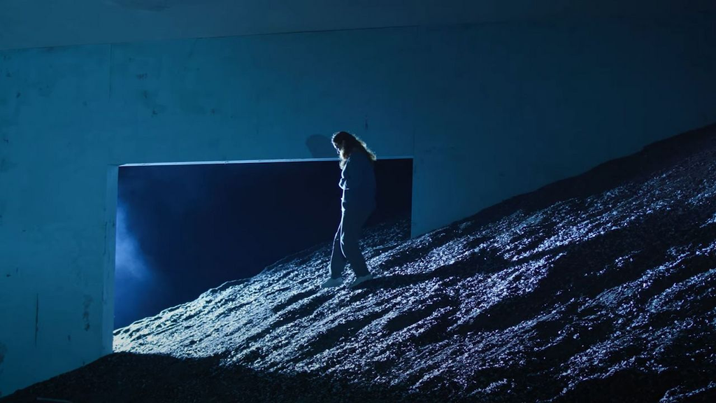

### Trailer zu AIDA

Zum Trailer

[figure not shown]

Zum Podcast

[figure not shown]

Zum Podcast

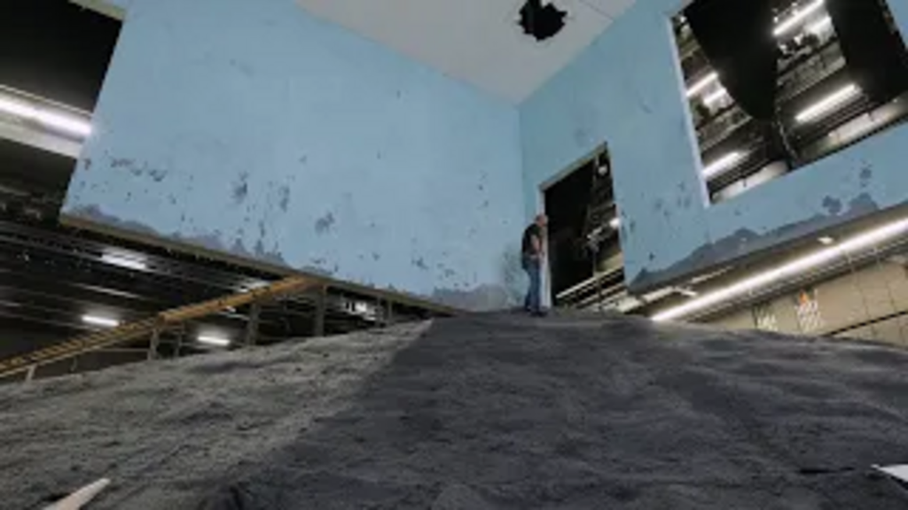

### Observations

Hier ansehen

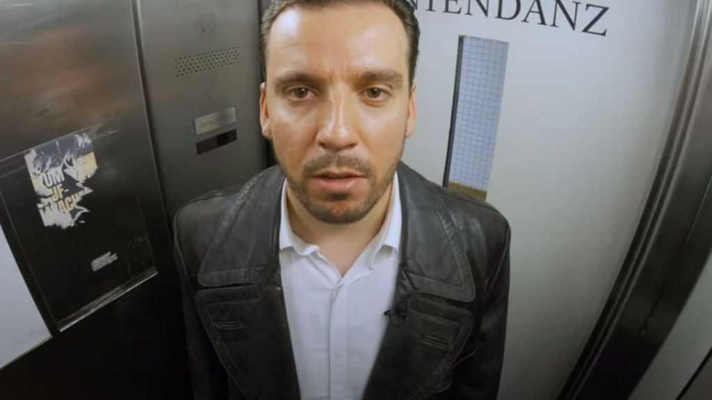

### Lift the Pitch

Hier ansehen

[figure not shown]

### Video-on-Demand

Hier ansehen

## ARTIKEL ZU AIDA

### Lesen Sie hier Interviews und Artikel zu unserer Neuproduktion von Giuseppe Verdis *Aida*

[figure not shown]

#### Brief

**Liebe Aida**

Von Annabelle Hirsch

HIER LESEN

[figure not shown]

#### Artikel

**Menschen haben die trügerische Hoffnung, dass die Entladung der Gewalt die Gewalt bremst.**

HIER LESEN

[figure not shown]

#### Interview

**Mich interessiert der Fokus auf alles Militärische nicht.**

Interview mit Regisseur Damiano Michieletto.

HIER LESEN

**Liebe Aida**

Von Annabelle Hirsch

HIER LESEN

[figure not shown]

#### Artikel

**Menschen haben die trügerische Hoffnung, dass die Entladung der Gewalt die Gewalt bremst.**

Andreas Zick über Gruppenkonflikte, Identitätsvorstellungen als Ursache von Gewalt und deren…

HIER LESEN

[figure not shown]

#### Interview

**Mich interessiert der Fokus auf alles Militärische nicht.**

Interview mit Regisseur Damiano Michieletto.

HIER LESEN

[figure not shown]

#### Brief

**Liebe Aida**

Von Annabelle Hirsch

HIER LESEN

[figure not shown]

Zugehörige Produkte im Opern ShopAkkordeon umschalten

[figure not shown]

##### Aida (Programm)

[Zum Opern Shop](https://tickets.staatstheater.bayern/bso.webshop/webticket/shop?language=de&item=672)

Vergangene VorstellungenAkkordeon umschalten

23. Juli 2023.7.23*Sonntag**So*

19.00 Uhr | Nationaltheater | *Oper für alle*

### Aida

Giuseppe Verdi

Oper

Oper

7. Juni 2023.6.23*Mittwoch**Mi*

19.00 Uhr | Nationaltheater

### Aida

Giuseppe Verdi

Oper

Oper

4. Juni 2023.6.23*Sonntag**So*

18.00 Uhr | Nationaltheater

### Aida

Giuseppe Verdi

Oper

Oper

mehr anzeigen

## Das könnte Sie auch Interessieren

[figure not shown]

#### Semele

Zum Stück

[figure not shown]

#### Don Carlo

Oper in fünf Akten (1867) empfohlen ab 16 Jahren

Zum Stück

[figure not shown]

#### Così fan tutte

Dramma giocoso in zwei Akten (1790) empfohlen ab 14 Jahren Libretto von Lorenzo Da Ponte

Zum Stück

Oper nach Art eines Oratoriums (1743) empfohlen ab 15 Jahren Eine Koproduktion mit der…

Zum Stück

[figure not shown]

#### Don Carlo

Oper in fünf Akten (1867) empfohlen ab 16 Jahren

Zum Stück

[figure not shown]

#### Così fan tutte

Dramma giocoso in zwei Akten (1790) empfohlen ab 14 Jahren Libretto von Lorenzo Da Ponte

Zum Stück

[figure not shown]

#### Semele

Oper nach Art eines Oratoriums (1743) empfohlen ab 15 Jahren Eine Koproduktion mit der…

Zum Stück

[figure not shown]

#### Don Carlo

Oper in fünf Akten (1867) empfohlen ab 16 Jahren

Zum Stück

[figure not shown]

#### Così fan tutte

Dramma giocoso in zwei Akten (1790) empfohlen ab 14 Jahren Libretto von Lorenzo Da Ponte

Zum Stück

[figure not shown]

#### Semele

Oper nach Art eines Oratoriums (1743) empfohlen ab 15 Jahren Eine Koproduktion mit der…

Zum Stück

[figure not shown]

#### Don Carlo

Oper in fünf Akten (1867) empfohlen ab 16 Jahren

Zum Stück

[figure not shown]

#### Così fan tutte

Dramma giocoso in zwei Akten (1790) empfohlen ab 14 Jahren Libretto von Lorenzo Da Ponte

Zum Stück

[figure not shown]

#### Semele

Oper nach Art eines Oratoriums (1743) empfohlen ab 15 Jahren Eine Koproduktion mit der…

Zum Stück

**Juli**2023

3

4

5

6

7

8

9

10

11

12

13

14

15

16

17

18

19

20

21

22

23

24

25

26

27

28

29

30

31

25. Juli 2023.7.23*Dienstag**Di*

19.00 Uhr | Prinzregententheater

### Semele

Oper

Oper

ausverkauftausverk.

25. Juli 2023.7.23*Dienstag**Di*

19.00 Uhr | Nationaltheater

### Festspiel-Liederabend Piotr Beczała

Liederabend

Liederabend

[Tickets](https://tickets.staatstheater.bayern/bso.webshop/webticket/shop?language=de&event=35055)

[Termin merken](https://www.staatsoper.de/stuecke/festspiel-liederabend-piotr-beczala/2023-07-25-1900-14519/calendar.ics)

26. Juli 2023.7.23*Mittwoch**Mi*

14.00 Uhr | Freunde-Foyer (Eingang Nord, Alfons-Goppel-Straße)

### Führung

Extra

Extra

ausverkauftausverk.

26. Juli 2023.7.23*Mittwoch**Mi*

14.00 Uhr | Freunde-Foyer (Eingang Nord, Alfons-Goppel-Straße)

### Guided tour of the Nationaltheater

Extra

Extra

[Tickets](https://tickets.staatstheater.bayern/bso.webshop/webticket/shop?language=de&event=37075)

[Termin merken](https://www.staatsoper.de/stuecke/guided-tour-of-the-national-theatre/26-07-2023-1400-14440/calendar.ics)

26. Juli 2023.7.23*Mittwoch**Mi*

17.00 Uhr | Stufen Nationaltheater

### Apollon Stufennacht

Offstage 360

Offstage 360

27. Juli 2023.7.23*Donnerstag**Do*

19.00 Uhr | Nationaltheater

### Aida

Oper

Oper

[Tickets](https://tickets.staatstheater.bayern/bso.webshop/webticket/shop?language=de&event=34788)

[Termin merken](https://www.staatsoper.de/stuecke/aida/2023-07-27-1900-13455/calendar.ics)

27. Juli 2023.7.23*Donnerstag**Do*

20.00 Uhr | Cuvilliés-Theater

### 4. Festspiel-Kammerkonzert: RECITAL PASCAL DEUBER

Konzert

Konzert

[Tickets](https://tickets.staatstheater.bayern/bso.webshop/webticket/shop?language=de&event=35050)

[Termin merken](https://www.staatsoper.de/stuecke/4-festspiel-kammerkonzert-2022-23/2023-07-27-2000-13456/calendar.ics)

28. Juli 2023.7.23*Freitag**Fr*

14.00 Uhr | Freunde-Foyer (Eingang Nord, Alfons-Goppel-Straße)

### Führung

Extra

Extra

[Tickets](https://tickets.staatstheater.bayern/bso.webshop/webticket/shop?language=de&event=37058)

[Termin merken](https://www.staatsoper.de/stuecke/fuehrung/28-07-2023-1400-14423/calendar.ics)

28. Juli 2023.7.23*Freitag**Fr*

14.00 Uhr | Freunde-Foyer (Eingang Nord, Alfons-Goppel-Straße)

### Guided tour of the Nationaltheater

Extra

Extra

[Tickets](https://tickets.staatstheater.bayern/bso.webshop/webticket/shop?language=de&event=37076)

[Termin merken](https://www.staatsoper.de/stuecke/guided-tour-of-the-national-theatre/28-07-2023-1400-14441/calendar.ics)

28. Juli 2023.7.23*Freitag**Fr*

18.00 Uhr | Nationaltheater

### DON CARLO

Oper

Oper

[Tickets](https://tickets.staatstheater.bayern/bso.webshop/webticket/shop?language=de&event=34862)

[Termin merken](https://www.staatsoper.de/stuecke/don-carlo/2023-07-28-1800-13457/calendar.ics)

29. Juli 2023.7.23*Samstag**Sa*

14.00 Uhr | Freunde-Foyer (Eingang Nord, Alfons-Goppel-Straße)

### Führung

Extra

Extra

[Tickets](https://tickets.staatstheater.bayern/bso.webshop/webticket/shop?language=de&event=37059)

[Termin merken](https://www.staatsoper.de/stuecke/fuehrung/29-07-2023-1400-14422/calendar.ics)

29. Juli 2023.7.23*Samstag**Sa*

14.00 Uhr | Freunde-Foyer (Eingang Nord, Alfons-Goppel-Straße)

### Kinderführung durch das Nationaltheater "Abenteuer Oper"

Extra

Extra

[Tickets](https://tickets.staatstheater.bayern/bso.webshop/webticket/shop?language=de&event=37067)

[Termin merken](https://www.staatsoper.de/stuecke/kinderfuehrung-durch-das-nationaltheater-abenteuer-oper/29-07-2023-1400-14431/calendar.ics)

29. Juli 2023.7.23*Samstag**Sa*

14.45 Uhr | Deutsches Theatermuseum München

### Kurzführung "In meiner Vorstellung"

Extra

Extra

29. Juli 2023.7.23*Samstag**Sa*

16.00 Uhr | Nationaltheater

### TRISTAN UND ISOLDE

Oper

Oper

[Tickets](https://tickets.staatstheater.bayern/bso.webshop/webticket/shop?language=de&event=35030)

[Termin merken](https://www.staatsoper.de/stuecke/tristan-und-isolde/2023-07-29-1600-13458/calendar.ics)

30. Juli 2023.7.23*Sonntag**So*

16.00 Uhr | Deutsches Theatermuseum München

### Kurzführung "In meiner Vorstellung"

Extra

Extra

30. Juli 2023.7.23*Sonntag**So*

16.45 Uhr | Deutsches Theatermuseum München

### Kurzführung "In meiner Vorstellung"

Extra

Extra

30. Juli 2023.7.23*Sonntag**So*

18.00 Uhr | Nationaltheater

### Aida

Oper

Oper

[Tickets](https://tickets.staatstheater.bayern/bso.webshop/webticket/shop?language=de&event=34789)

[Termin merken](https://www.staatsoper.de/stuecke/aida/2023-07-30-1800-13459/calendar.ics)

31. Juli 2023.7.23*Montag**Mo*

18.00 Uhr | Nationaltheater

### DON CARLO

Oper

Oper

[Tickets](https://tickets.staatstheater.bayern/bso.webshop/webticket/shop?language=de&event=34863)

[Termin merken](https://www.staatsoper.de/stuecke/don-carlo/2023-07-31-1800-13460/calendar.ics)